# Valeur client et fidélisation

Projet n° 5 — Data Science sous R (ESME, 2026-2027)

Auteur·rice·s

Chris Boupassaia

Bertrand De Vertreuil

Améziane Haouanoh

Léonie Schmit

Date de publication

27 octobre 2026

**ImportantMode d’emploi du modèle (à supprimer avant le rendu final)**

- Ce document est le **rapport technique** du projet. Le résumé exécutif (2 pages, pour un public non technique) est un document séparé : modèle LaTeX `resume-executif.tex`, dans ce même dossier.
- Remplacez le titre, le numéro du projet et les noms ci-dessus.
- Indiquez le numéro de votre projet dans le bloc `configuration` ci-dessous : les données correspondantes sont chargées automatiquement.
- Les encadrés « Consigne » expliquent ce qui est attendu dans chaque section : **supprimez-les** une fois la section rédigée.
- Le rapport doit se produire **de bout en bout** avec le bouton *Render* de RStudio (ou `quarto render rapport.qmd`), sans erreur, à partir des données d’origine.
- Rangez les fonctions réutilisables dans `R/fonctions.R`.

# Résumé

**NoteConsigne**

Trois à cinq phrases : la question, les données, la méthode, le **résultat principal** (chiffré) et la **recommandation**, puis la principale limite. Rédigez cette partie en dernier.

# 1 Contexte et question

**NoteConsigne**

- Présentez la situation et le **problème marketing**.
- Formulez une **question précise**, à laquelle les données peuvent répondre.
- Indiquez la **décision** que l’analyse doit éclairer et le **critère de succès** (par exemple : « prédire la souscription mieux que le ciblage actuel », « classer les leviers de satisfaction »).

# 2 Données

## 2.1 Origine et contenu

**NoteConsigne**

D’où viennent les données ? Qui les a collectées, comment, quand, dans quel but ? Que représente une ligne ? Les données sont-elles réelles ou simulées ? Citez la source (par exemple, Yu et Barter 2024).

```r
donnees <- charger_donnees(5)
dim(donnees)
```

```
[1] 9508   12
```

```r
glimpse(donnees)
```

```
Rows: 9,508
Columns: 12
$ client_id         <chr> "C0001", "C0001", "C0001", "C0001", "C0001", "C0001"…
$ commande_id       <chr> "K07132", "K02140", "K05787", "K06110", "K09164", "K…
$ date              <date> 2025-11-10, 2025-04-14, 2025-09-25, 2025-10-08, 202…
$ categorie         <chr> "Mode", "High-tech", "Mode", "Maison", "Mode", "Mais…
$ nb_articles       <int> 1, 2, 2, 2, 1, 2, 4, 1, 3, 4, 1, 3, 3, 2, 2, 2, 2, 5…
$ promo             <lgl> FALSE, FALSE, FALSE, FALSE, FALSE, FALSE, FALSE, TRU…
$ montant           <dbl> 72.46, 55.55, 77.16, 152.15, 80.49, 62.25, 137.97, 1…
$ age               <int> 62, 62, 62, 62, 62, 62, 62, 62, 39, 39, 39, 39, 39, …
$ region            <chr> "Île-de-France", "Île-de-France", "Île-de-France", "…
$ canal_acquisition <chr> "Réseaux sociaux", "Réseaux sociaux", "Réseaux socia…
$ date_inscription  <date> 2023-10-25, 2023-10-25, 2023-10-25, 2023-10-25, 202…
$ newsletter        <chr> "Oui", "Oui", "Oui", "Oui", "Oui", "Oui", "Oui", "Ou…
```

## 2.2 Dictionnaire des variables

**NoteConsigne**

Complétez la colonne *Description* : signification de chaque variable, unité, modalités. Pour un jeu de données très large, ne détaillez que les variables utilisées et décrivez les autres par groupes.

```r
tibble(
  Variable = names(donnees),
  Type = map_chr(donnees, \(x) class(x)[1]),
  Description = "À compléter"
) |>
  head(25) |>
  kable()
```

Table 1: Variables du jeu de données

[output not shown]

## 2.3 Qualité des données

**NoteConsigne**

Valeurs manquantes, doublons, valeurs aberrantes ou incohérentes, représentativité. Pour chaque problème : comment le traitez-vous, et pourquoi ?

```r
manquants <- tibble(
  Variable = names(donnees),
  `Valeurs manquantes` = colSums(is.na(donnees)),
  `Part (%)` = round(100 * colMeans(is.na(donnees)), 1)
) |>
  filter(`Valeurs manquantes` > 0)

if (nrow(manquants) == 0) {
  tibble(Résultat = "Aucune valeur manquante") |> kable()
} else {
  kable(manquants)
}
```

Table 2: Valeurs manquantes par variable (variables concernées uniquement)

| Variable | Valeurs manquantes | Part (%) |
| --- | --- | --- |
| age | 278 | 2.9 |

Nombre de lignes en double : 0.

## 2.4 Éthique et cadre légal

**NoteConsigne**

Les données décrivent-elles des personnes ? Sont-elles identifiantes ? Un usage de vos résultats pourrait-il être discriminatoire ou intrusif (ciblage, prix, exclusion) ? Quelles précautions proposez-vous ?

# 3 Préparation des données

**NoteConsigne**

Décrivez et justifiez chaque transformation : recodages, variables créées, traitement des valeurs manquantes, filtres. Ces choix peuvent influencer les résultats : notez-les pour en tester l’effet (section « Évaluation »).

```r
donnees_propres <- donnees
# Exemple : donnees_propres <- donnees |> mutate(...) |> filter(...)
```

**Découpage entraînement / test.** Pour un objectif de prédiction, réservez un jeu de test **avant** toute exploration, avec un découpage adapté (aléatoire, temporel ou par groupes).

```r
indices_train <- sample(nrow(donnees_propres), size = round(0.7 * nrow(donnees_propres)))
train <- donnees_propres[indices_train, ]
test  <- donnees_propres[-indices_train, ]
c(entrainement = nrow(train), test = nrow(test))
```

```
entrainement         test
        6656         2852
```

# 4 Exploration

**NoteConsigne**

Analyses univariées puis bivariées, **sur le jeu d’entraînement**, orientées vers la question. Chaque graphique a un titre qui énonce son message, des axes avec unités, et il est **commenté** dans le texte (par exemple « la Figure 1 montre que… »). Gardez les graphiques utiles, pas tous ceux que vous avez produits.

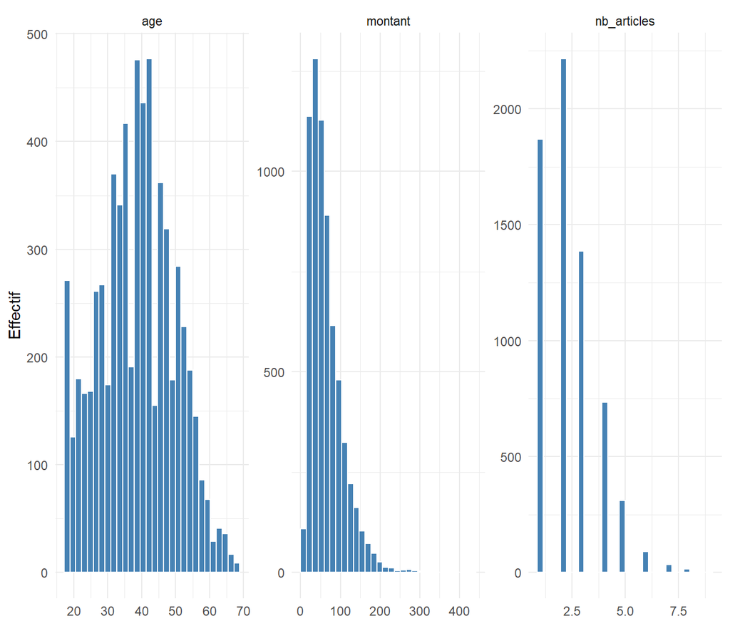

Figure 1: Distribution des variables quantitatives (12 premières au plus)

```r
quantitatives <- train |> select(where(is.numeric))
if (ncol(quantitatives) > 0) {
  quantitatives |>
    select(1:min(12, ncol(quantitatives))) |>
    pivot_longer(everything(), names_to = "variable", values_to = "valeur") |>
    ggplot(aes(x = valeur)) +
    geom_histogram(bins = 30, fill = "steelblue", color = "white") +
    facet_wrap(vars(variable), scales = "free") +
    labs(x = NULL, y = "Effectif")
}
```

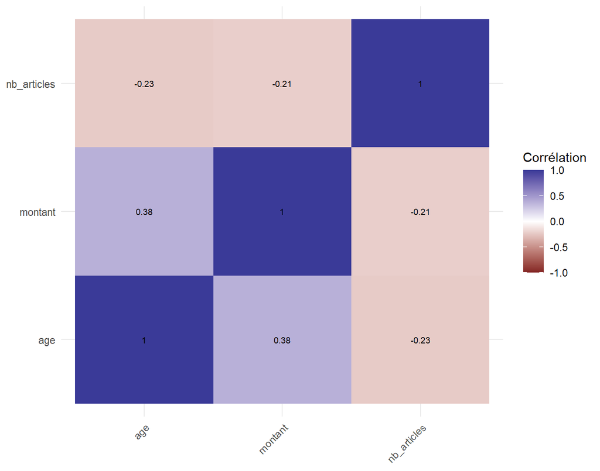

Figure 2: Corrélations entre les variables quantitatives (12 premières au plus)

```r
if (ncol(quantitatives) >= 2) {
  quantitatives |>
    select(1:min(12, ncol(quantitatives))) |>
    cor(use = "pairwise.complete.obs") |>
    as.data.frame() |>
    rownames_to_column("variable_1") |>
    pivot_longer(-variable_1, names_to = "variable_2", values_to = "correlation") |>
    ggplot(aes(variable_1, variable_2, fill = correlation)) +
    geom_tile() +
    geom_text(aes(label = round(correlation, 2)), size = 2.5) +
    scale_fill_gradient2(limits = c(-1, 1)) +
    labs(x = NULL, y = NULL, fill = "Corrélation") +
    theme(axis.text.x = element_text(angle = 45, hjust = 1))
}
```

# 5 Modélisation

**NoteConsigne**

- Commencez par un **modèle de référence** très simple (prédire la moyenne ou la classe majoritaire).
- Présentez ensuite les méthodes retenues et **justifiez** leur choix par rapport à la question et au type des variables (régression, ANOVA, ACP, arbres, forêts aléatoires, classification automatique…).
- Interprétez les résultats dans les termes du problème marketing.

Les blocs ci-dessous sont des **exemples** à adapter (ils ne sont pas exécutés : remplacez `#| eval: false` par `#| eval: true`).

```r
# Exemple : prédire une variable quantitative `cible`
reference <- mean(train$cible)
modele_lineaire <- lm(cible ~ ., data = train)
summary(modele_lineaire)

library(randomForest)
foret <- randomForest(cible ~ ., data = train, importance = TRUE)
varImpPlot(foret)
```

```r
# Exemple : prédire une variable qualitative à deux modalités `cible`
logistique <- glm(cible ~ ., data = train, family = binomial)
summary(logistique)
exp(coef(logistique))              # rapports de cotes

library(rpart)
arbre <- rpart(cible ~ ., data = train, method = "class")
```

```r
# Exemple : résumer et segmenter (ACP puis classification)
library(FactoMineR)
library(factoextra)
acp <- PCA(quantitatives, graph = FALSE)
fviz_pca_var(acp)
segments <- kmeans(scale(quantitatives), centers = 4, nstart = 25)
```

# 6 Évaluation

**NoteConsigne**

- **Prédictibilité** : performances sur le jeu de **test**, comparées au modèle de référence (RMSE ; ou matrice de confusion, sensibilité, spécificité, AUC).
- **Stabilité** : les conclusions changent-elles avec une autre graine, un autre traitement des valeurs manquantes, une autre méthode ?
- Résumez les performances dans un tableau.

```r
tibble(
  Modèle = c("Référence (moyenne)", "Régression linéaire", "Forêt aléatoire"),
  RMSE = c(rmse(test$cible, reference),
           rmse(test$cible, predict(modele_lineaire, test)),
           rmse(test$cible, predict(foret, test)))
) |>
  kable(digits = 2)
```

# 7 Résultats et recommandations

**NoteConsigne**

Le message principal en une phrase, puis des recommandations **concrètes, chiffrées et réalisables** pour l’équipe marketing, avec leur effet attendu. Exportez le graphique qui porte le message principal : il sera repris dans le résumé exécutif.

```r
# Exemple : enregistrer le graphique principal pour le résumé exécutif
ggsave("figures/figure-cle.pdf", plot = graphique_principal, width = 7, height = 3.5)
```

# 8 Limites et perspectives

**NoteConsigne**

Limites des données (représentativité, variables manquantes, données simulées), des méthodes (associations et non causalité, hypothèses), et ce que vous feriez avec plus de temps ou de données (par exemple : un test A/B).

# Annexes

## Contribution des membres du groupe

[output not shown]

## Références

Yu, Bin, et Rebecca L. Barter. 2024. *Veridical Data Science: The Practice of Responsible Data Analysis and Decision Making*. MIT Press.